# Work Group Meeting 2

Noverber 23, 2023

## This Workgroup Meeting

### 1. Some examples on processing

### 2. Continue with processing of the data set

## Assignment 1

- **Introduction:** Introduction of your research questions, description and potential processing of your data. (week 1 & 2)
- **Exploratory data analysis:** Inspection of potential interesting relations in the data. (week 3)
- **Linear regression:** Description of the building process, the model fit, and the model comparison procedure. (week 4)
- **Assumptions:** Testing of model assumptions, checking for outliers and influential cases. Act upon and reflect on violations when needed.
- **Interpretation:** Substantive interpretation of the final model. Answers to your research questions. (week 5)
- **Layout:** Structure of the document, output is efficiently presented, custom functions are developed when needed. Graphs are used where fitting.

*Find the complete assignment description on the course web site.*

## Processing Examples - 1

### Incorrect variable classes

Character classes are not always automatically set correctly, see for example the picture below. These classes should be adjusted with functions as `as_factor()` or `as_numeric()`.

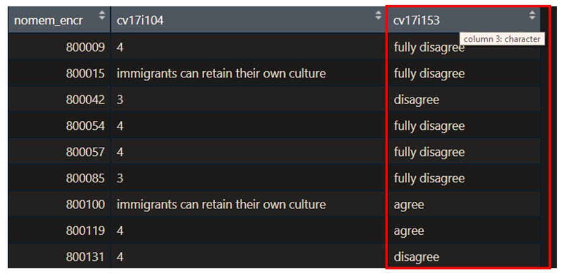

## Processing Examples - 2

### NA’s as categories/Recoding of variables

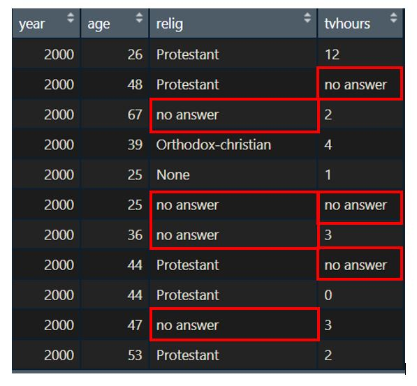

## Processing Examples - 3

### Total scores & Sum scores

Some variables need to be computed into new variables, such as scale totals in the example below.

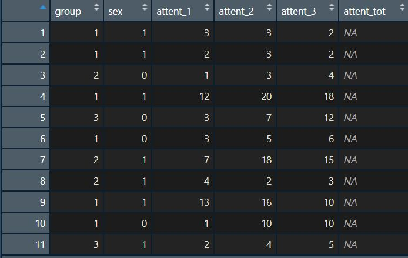

## Processing Examples - 4

### Linking data sets

When 2 data sets need to be combined, you can simply bind them `rbind(df1, df2)` for new observations (rows), or `cbind(df1, df2)` when new variables can be added together (same observations).

If, however, only some observations are the same, you can join the two data frames (`full_join(df1, df2, by = "identification_variable")`). This could be used for the 2 data frames shown below.

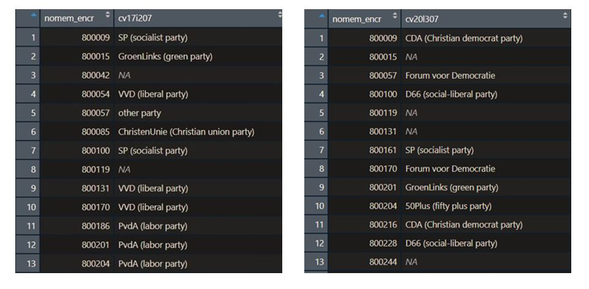

## Remainder of the meeting

### Continue with preprocessing your data set, this should ideally be finished at the end of this meeting.

## For the next meeting

### Keep working on Assignment 1